# **Using Linear Regression to find relationships between sleep and an active lifestyle**

#### **By:** Bhavin Dinesh Bhatt, Mubtasim Haque Talha, Cody Boleyn

#### **Preface:** As per Dr. Hetricks discussion regarding academic integrity, we want to disclose that we have used ChatGPT to help build the outline of some of the syntax used below. We hope that this isn't taken as dishonesty and wanted to insure you that we used it only as a reference for writing syntax.

## **Dataset:**

FitBit Fitness Tracker Data

https://www.kaggle.com/datasets/arashnic/fitbit

It contains data from survey respondents who were Fitbit users between March 12, 2016 and May 12, 2016. The data includes various measures of physical activity, such as total distance covered, total steps taken, average intensity of activity, time spent in 4 varying levels of activity (sedentary, light, fair, very). There are also records of the respondents' sleep activity, including their time spent in bed and time spent sleeping, both in minutes.

## **Objective 1:**

#### Understanding Sleep Patterns: The primary objective of conducting a linear regression analysis on Fitbit data is to gain a comprehensive understanding of the relationship between sleep activity and various physical and lifestyle factors. By exploring how sleep quality (dependent variable) is influenced by independent variables such as Activity Score, Total Steps, Total Distance, Calories, and Average Intensity, we aim to uncover patterns and insights that can inform individuals about the impact of their daily activities on their sleep. This analysis will enable us to quantitatively assess which factors contribute positively or negatively to sleep quality and identify areas for potential improvement.

## **Objective 2:**

#### Predictive Modeling and Health Optimization: Another key objective is to develop a predictive model that can accurately forecast sleep activity based on the selected independent variables. This predictive capability will empower individuals to proactively manage their sleep patterns by adjusting their physical activity levels, caloric intake, and other lifestyle factors. The model can serve as a valuable tool for making data-driven decisions to optimize sleep quality and overall health. Ultimately, the goal is to provide actionable insights and personalized recommendations that promote better sleep habits, leading to improved well-being and quality of life. Through this analysis, we aim to bridge the gap between lifestyle choices and sleep outcomes, offering individuals a data-driven approach to achieving healthier and more restful sleep patterns.

## **Stakeholders:**

#### Fitbit users, the primary stakeholders, can use analysis insights to optimize their health by adjusting daily routines. Healthcare professionals and wellness coaches are secondary stakeholders who can provide data-driven guidance to patients and clients for improved sleep and physical activity, enhancing overall well-being.

## **2) Data Exploration:**

#### The goal of this step is to import three seperate csv file relating to sleep, daily activities and the intensity of those activites. We will then examine each csv file and try to get an understanding of what the data looks like.

```r
#Import three different csv files
activity_df <- read.csv("dailyActivity_merged.csv")
sleep_df <- read.csv("sleepDay_merged.csv")
activity_intensity_df <- read.csv("hourlyIntensities_merged.csv")
```

#### 1) 4 different simple aspects of activity data

```r
# Rows and columns of the activity data
dim(activity_df)
# Column names of the activity data
names(activity_df)
# Displaying the first 6 rows of the activity data
head(activity_df)
# Displaying descriptive statistics for each feature of the activity data
summary(activity_df)
```

1. 940

2. 15

1. 'Id'

2. 'Date'

3. 'TotalSteps'

4. 'TotalDistance'

5. 'TrackerDistance'

6. 'LoggedActivitiesDistance'

7. 'VeryActiveDistance'

8. 'ModeratelyActiveDistance'

9. 'LightActiveDistance'

10. 'SedentaryActiveDistance'

11. 'VeryActiveMinutes'

12. 'FairlyActiveMinutes'

13. 'LightlyActiveMinutes'

14. 'SedentaryMinutes'

15. 'Calories'

A data.frame: 6 × 15

|  | Id <dbl> | Date <chr> | TotalSteps <int> | TotalDistance <dbl> | TrackerDistance <dbl> | LoggedActivitiesDistance <dbl> | VeryActiveDistance <dbl> | ModeratelyActiveDistance <dbl> | LightActiveDistance <dbl> | SedentaryActiveDistance <dbl> | VeryActiveMinutes <int> | FairlyActiveMinutes <int> | LightlyActiveMinutes <int> | SedentaryMinutes <int> | Calories <int> |
| --- | --- | --- | --- | --- | --- | --- | --- | --- | --- | --- | --- | --- | --- | --- | --- |
| 1 | 1503960366 | 4/12/2016 | 13162 | 8.50 | 8.50 | 0 | 1.88 | 0.55 | 6.06 | 0 | 25 | 13 | 328 | 728 | 1985 |
| 2 | 1503960366 | 4/13/2016 | 10735 | 6.97 | 6.97 | 0 | 1.57 | 0.69 | 4.71 | 0 | 21 | 19 | 217 | 776 | 1797 |
| 3 | 1503960366 | 4/14/2016 | 10460 | 6.74 | 6.74 | 0 | 2.44 | 0.40 | 3.91 | 0 | 30 | 11 | 181 | 1218 | 1776 |
| 4 | 1503960366 | 4/15/2016 | 9762 | 6.28 | 6.28 | 0 | 2.14 | 1.26 | 2.83 | 0 | 29 | 34 | 209 | 726 | 1745 |
| 5 | 1503960366 | 4/16/2016 | 12669 | 8.16 | 8.16 | 0 | 2.71 | 0.41 | 5.04 | 0 | 36 | 10 | 221 | 773 | 1863 |
| 6 | 1503960366 | 4/17/2016 | 9705 | 6.48 | 6.48 | 0 | 3.19 | 0.78 | 2.51 | 0 | 38 | 20 | 164 | 539 | 1728 |

```
       Id                Date             TotalSteps    TotalDistance
 Min.   :1.504e+09   Length:940         Min.   :    0   Min.   : 0.000
 1st Qu.:2.320e+09   Class :character   1st Qu.: 3790   1st Qu.: 2.620
 Median :4.445e+09   Mode  :character   Median : 7406   Median : 5.245
 Mean   :4.855e+09                      Mean   : 7638   Mean   : 5.490
 3rd Qu.:6.962e+09                      3rd Qu.:10727   3rd Qu.: 7.713
 Max.   :8.878e+09                      Max.   :36019   Max.   :28.030
 TrackerDistance  LoggedActivitiesDistance VeryActiveDistance
 Min.   : 0.000   Min.   :0.0000           Min.   : 0.000
 1st Qu.: 2.620   1st Qu.:0.0000           1st Qu.: 0.000
 Median : 5.245   Median :0.0000           Median : 0.210
 Mean   : 5.475   Mean   :0.1082           Mean   : 1.503
 3rd Qu.: 7.710   3rd Qu.:0.0000           3rd Qu.: 2.053
 Max.   :28.030   Max.   :4.9421           Max.   :21.920
 ModeratelyActiveDistance LightActiveDistance SedentaryActiveDistance
 Min.   :0.0000           Min.   : 0.000      Min.   :0.000000
 1st Qu.:0.0000           1st Qu.: 1.945      1st Qu.:0.000000
 Median :0.2400           Median : 3.365      Median :0.000000
 Mean   :0.5675           Mean   : 3.341      Mean   :0.001606
 3rd Qu.:0.8000           3rd Qu.: 4.782      3rd Qu.:0.000000
 Max.   :6.4800           Max.   :10.710      Max.   :0.110000
 VeryActiveMinutes FairlyActiveMinutes LightlyActiveMinutes SedentaryMinutes
 Min.   :  0.00    Min.   :  0.00      Min.   :  0.0        Min.   :   0.0
 1st Qu.:  0.00    1st Qu.:  0.00      1st Qu.:127.0        1st Qu.: 729.8
 Median :  4.00    Median :  6.00      Median :199.0        Median :1057.5
 Mean   : 21.16    Mean   : 13.56      Mean   :192.8        Mean   : 991.2
 3rd Qu.: 32.00    3rd Qu.: 19.00      3rd Qu.:264.0        3rd Qu.:1229.5
 Max.   :210.00    Max.   :143.00      Max.   :518.0        Max.   :1440.0
    Calories
 Min.   :   0
 1st Qu.:1828
 Median :2134
 Mean   :2304
 3rd Qu.:2793
 Max.   :4900
```

#### 2) 4 different simple aspects of sleep data

```r
dim(sleep_df)
names(sleep_df)
head(sleep_df)
summary(sleep_df)
```

1. 413

2. 5

1. 'Id'

2. 'Date'

3. 'TotalSleepRecords'

4. 'TotalMinutesAsleep'

5. 'TotalTimeInBed'

A data.frame: 6 × 5

|  | Id <dbl> | Date <chr> | TotalSleepRecords <int> | TotalMinutesAsleep <int> | TotalTimeInBed <int> |
| --- | --- | --- | --- | --- | --- |
| 1 | 1503960366 | 4/12/2016 | 1 | 327 | 346 |
| 2 | 1503960366 | 4/13/2016 | 2 | 384 | 407 |
| 3 | 1503960366 | 4/15/2016 | 1 | 412 | 442 |
| 4 | 1503960366 | 4/16/2016 | 2 | 340 | 367 |
| 5 | 1503960366 | 4/17/2016 | 1 | 700 | 712 |
| 6 | 1503960366 | 4/19/2016 | 1 | 304 | 320 |

```
       Id                Date           TotalSleepRecords TotalMinutesAsleep
 Min.   :1.504e+09   Length:413         Min.   :1.000     Min.   : 58.0
 1st Qu.:3.977e+09   Class :character   1st Qu.:1.000     1st Qu.:361.0
 Median :4.703e+09   Mode  :character   Median :1.000     Median :433.0
 Mean   :5.001e+09                      Mean   :1.119     Mean   :419.5
 3rd Qu.:6.962e+09                      3rd Qu.:1.000     3rd Qu.:490.0
 Max.   :8.792e+09                      Max.   :3.000     Max.   :796.0
 TotalTimeInBed
 Min.   : 61.0
 1st Qu.:403.0
 Median :463.0
 Mean   :458.6
 3rd Qu.:526.0
 Max.   :961.0
```

#### 3) 4 different simple aspects of the intensity of activity data

```r
dim(activity_intensity_df)
names(activity_intensity_df)
head(activity_intensity_df)
summary(activity_intensity_df)
```

1. 22099

2. 4

1. 'Id'

2. 'Date'

3. 'TotalIntensity'

4. 'AverageIntensity'

A data.frame: 6 × 4

|  | Id <dbl> | Date <chr> | TotalIntensity <int> | AverageIntensity <dbl> |
| --- | --- | --- | --- | --- |
| 1 | 1503960366 | 4/12/2016 | 20 | 0.333333 |
| 2 | 1503960366 | 4/12/2016 | 8 | 0.133333 |
| 3 | 1503960366 | 4/12/2016 | 7 | 0.116667 |
| 4 | 1503960366 | 4/12/2016 | 0 | 0.000000 |
| 5 | 1503960366 | 4/12/2016 | 0 | 0.000000 |
| 6 | 1503960366 | 4/12/2016 | 0 | 0.000000 |

```
       Id                Date           TotalIntensity   AverageIntensity
 Min.   :1.504e+09   Length:22099       Min.   :  0.00   Min.   :0.0000
 1st Qu.:2.320e+09   Class :character   1st Qu.:  0.00   1st Qu.:0.0000
 Median :4.445e+09   Mode  :character   Median :  3.00   Median :0.0500
 Mean   :4.848e+09                      Mean   : 12.04   Mean   :0.2006
 3rd Qu.:6.962e+09                      3rd Qu.: 16.00   3rd Qu.:0.2667
 Max.   :8.878e+09                      Max.   :180.00   Max.   :3.0000
```

#### Results: After taking a simple look at the data, we can see that the datasets can be merged on the ID and Date features. The areas of interest in the data lie within the differnet levels of activity Light, Fairly, and Very Active Minutes, as well as the Intensity Levels. This data can then be compared to the amount of sleep an individual gets, which lies in the column "TotalMinutesAsleep". As we can see the average amount of sleep for all the individuals in the dataset is 419.5 minute, which is just below 7 hours.

## **3) Data Cleaning:**

#### Below we cleaned and then merged the three csv files. We then removed the columns that we found to be unnecessary for this particular linear regression model. This will give a final combined dataset that is much more manageable to work with.

#### 1) Since there were multiple entries per day for each individual regarding the activity intensity, we decided to aggregate the data for the intensity level and consolidate them all into one day. This allows us to then use this newly created dataset to merge with the other two csv file, which only have one entry per day.

```r
averaged_data_df <- aggregate(cbind(TotalIntensity, AverageIntensity) ~ Id + Date, data = activity_intensity_df, FUN = mean)
head(averaged_data_df)
```

A data.frame: 6 × 4

|  | Id <dbl> | Date <chr> | TotalIntensity <dbl> | AverageIntensity <dbl> |
| --- | --- | --- | --- | --- |
| 1 | 1503960366 | 4/12/2016 | 17.875000 | 0.29791667 |
| 2 | 1624580081 | 4/12/2016 | 6.083333 | 0.10138892 |
| 3 | 1644430081 | 4/12/2016 | 15.166667 | 0.25277775 |
| 4 | 1844505072 | 4/12/2016 | 14.125000 | 0.23541662 |
| 5 | 1927972279 | 4/12/2016 | 2.291667 | 0.03819442 |
| 6 | 2022484408 | 4/12/2016 | 15.875000 | 0.26458338 |

2) Below, we conducted the first merge, with the daily activity and daily sleep datasets. We wanted to make sure that we kept all of the sleep data and discarded the data from daily activity that didn't have records for sleep on that day. We then printed the dimensions and dataset to make sure the merge worked and the total sleep record where maintained. The original sleep dataset has a total of 413 rows.

```r
activity_sleep_merged <- merge(activity_df, sleep_df, by=c("Id", "Date"))
```

```r
dim(activity_sleep_merged)
head(activity_sleep_merged)
```

1. 413

2. 18

A data.frame: 6 × 18

|  | Id <dbl> | Date <chr> | TotalSteps <int> | TotalDistance <dbl> | TrackerDistance <dbl> | LoggedActivitiesDistance <dbl> | VeryActiveDistance <dbl> | ModeratelyActiveDistance <dbl> | LightActiveDistance <dbl> | SedentaryActiveDistance <dbl> | VeryActiveMinutes <int> | FairlyActiveMinutes <int> | LightlyActiveMinutes <int> | SedentaryMinutes <int> | Calories <int> | TotalSleepRecords <int> | TotalMinutesAsleep <int> | TotalTimeInBed <int> |
| --- | --- | --- | --- | --- | --- | --- | --- | --- | --- | --- | --- | --- | --- | --- | --- | --- | --- | --- |
| 1 | 1503960366 | 4/12/2016 | 13162 | 8.50 | 8.50 | 0 | 1.88 | 0.55 | 6.06 | 0 | 25 | 13 | 328 | 728 | 1985 | 1 | 327 | 346 |
| 2 | 1503960366 | 4/13/2016 | 10735 | 6.97 | 6.97 | 0 | 1.57 | 0.69 | 4.71 | 0 | 21 | 19 | 217 | 776 | 1797 | 2 | 384 | 407 |
| 3 | 1503960366 | 4/15/2016 | 9762 | 6.28 | 6.28 | 0 | 2.14 | 1.26 | 2.83 | 0 | 29 | 34 | 209 | 726 | 1745 | 1 | 412 | 442 |
| 4 | 1503960366 | 4/16/2016 | 12669 | 8.16 | 8.16 | 0 | 2.71 | 0.41 | 5.04 | 0 | 36 | 10 | 221 | 773 | 1863 | 2 | 340 | 367 |
| 5 | 1503960366 | 4/17/2016 | 9705 | 6.48 | 6.48 | 0 | 3.19 | 0.78 | 2.51 | 0 | 38 | 20 | 164 | 539 | 1728 | 1 | 700 | 712 |
| 6 | 1503960366 | 4/19/2016 | 15506 | 9.88 | 9.88 | 0 | 3.53 | 1.32 | 5.03 | 0 | 50 | 31 | 264 | 775 | 2035 | 1 | 304 | 320 |

#### 3) With the two previous datasets merged, we then merged the last dataset with the aggregated intensity metrics. As you can see by the dimensions of the newly merged dataset below, it contains the same amount of rows as the original sleep dataset. This means that we have successfuly merged all records with the sleep dataset.

```r
FitBit_merged_data <- merge(activity_sleep_merged, averaged_data_df,  by=c("Id", "Date"))
```

```r
dim(FitBit_merged_data)
head(FitBit_merged_data)
```

1. 413

2. 20

A data.frame: 6 × 20

|  | Id <dbl> | Date <chr> | TotalSteps <int> | TotalDistance <dbl> | TrackerDistance <dbl> | LoggedActivitiesDistance <dbl> | VeryActiveDistance <dbl> | ModeratelyActiveDistance <dbl> | LightActiveDistance <dbl> | SedentaryActiveDistance <dbl> | VeryActiveMinutes <int> | FairlyActiveMinutes <int> | LightlyActiveMinutes <int> | SedentaryMinutes <int> | Calories <int> | TotalSleepRecords <int> | TotalMinutesAsleep <int> | TotalTimeInBed <int> | TotalIntensity <dbl> | AverageIntensity <dbl> |
| --- | --- | --- | --- | --- | --- | --- | --- | --- | --- | --- | --- | --- | --- | --- | --- | --- | --- | --- | --- | --- |
| 1 | 1503960366 | 4/12/2016 | 13162 | 8.50 | 8.50 | 0 | 1.88 | 0.55 | 6.06 | 0 | 25 | 13 | 328 | 728 | 1985 | 1 | 327 | 346 | 17.87500 | 0.2979167 |
| 2 | 1503960366 | 4/13/2016 | 10735 | 6.97 | 6.97 | 0 | 1.57 | 0.69 | 4.71 | 0 | 21 | 19 | 217 | 776 | 1797 | 2 | 384 | 407 | 13.25000 | 0.2208334 |
| 3 | 1503960366 | 4/15/2016 | 9762 | 6.28 | 6.28 | 0 | 2.14 | 1.26 | 2.83 | 0 | 29 | 34 | 209 | 726 | 1745 | 1 | 412 | 442 | 15.16667 | 0.2527777 |
| 4 | 1503960366 | 4/16/2016 | 12669 | 8.16 | 8.16 | 0 | 2.71 | 0.41 | 5.04 | 0 | 36 | 10 | 221 | 773 | 1863 | 2 | 340 | 367 | 14.54167 | 0.2423611 |
| 5 | 1503960366 | 4/17/2016 | 9705 | 6.48 | 6.48 | 0 | 3.19 | 0.78 | 2.51 | 0 | 38 | 20 | 164 | 539 | 1728 | 1 | 700 | 712 | 13.25000 | 0.2208333 |
| 6 | 1503960366 | 4/19/2016 | 15506 | 9.88 | 9.88 | 0 | 3.53 | 1.32 | 5.03 | 0 | 50 | 31 | 264 | 775 | 2035 | 1 | 304 | 320 | 19.83333 | 0.3305557 |

#### 4) Below, we removed the columns that won't be useful to our analysis by creating a subset of data

```r
subset_FitBit_data_df <- subset(FitBit_merged_data, select = -c(TrackerDistance, LoggedActivitiesDistance, VeryActiveDistance, LightActiveDistance, ModeratelyActiveDistance, SedentaryActiveDistance))
head(subset_FitBit_data_df)
```

A data.frame: 6 × 14

|  | Id <dbl> | Date <chr> | TotalSteps <int> | TotalDistance <dbl> | VeryActiveMinutes <int> | FairlyActiveMinutes <int> | LightlyActiveMinutes <int> | SedentaryMinutes <int> | Calories <int> | TotalSleepRecords <int> | TotalMinutesAsleep <int> | TotalTimeInBed <int> | TotalIntensity <dbl> | AverageIntensity <dbl> |
| --- | --- | --- | --- | --- | --- | --- | --- | --- | --- | --- | --- | --- | --- | --- |
| 1 | 1503960366 | 4/12/2016 | 13162 | 8.50 | 25 | 13 | 328 | 728 | 1985 | 1 | 327 | 346 | 17.87500 | 0.2979167 |
| 2 | 1503960366 | 4/13/2016 | 10735 | 6.97 | 21 | 19 | 217 | 776 | 1797 | 2 | 384 | 407 | 13.25000 | 0.2208334 |
| 3 | 1503960366 | 4/15/2016 | 9762 | 6.28 | 29 | 34 | 209 | 726 | 1745 | 1 | 412 | 442 | 15.16667 | 0.2527777 |
| 4 | 1503960366 | 4/16/2016 | 12669 | 8.16 | 36 | 10 | 221 | 773 | 1863 | 2 | 340 | 367 | 14.54167 | 0.2423611 |
| 5 | 1503960366 | 4/17/2016 | 9705 | 6.48 | 38 | 20 | 164 | 539 | 1728 | 1 | 700 | 712 | 13.25000 | 0.2208333 |
| 6 | 1503960366 | 4/19/2016 | 15506 | 9.88 | 50 | 31 | 264 | 775 | 2035 | 1 | 304 | 320 | 19.83333 | 0.3305557 |

## **4) Adaptation:**

#### Below we wanted to add some extra data points for comparision when doing the linear regression analysis between daily activity and sleep.

#### 1) Below we added a column that calculates the percentage of sleep

```r
subset_FitBit_data_df$Percentage_Asleep <- (subset_FitBit_data_df$TotalMinutesAsleep / subset_FitBit_data_df$TotalTimeInBed) * 100
head(subset_FitBit_data_df)
```

A data.frame: 6 × 15

|  | Id <dbl> | Date <chr> | TotalSteps <int> | TotalDistance <dbl> | VeryActiveMinutes <int> | FairlyActiveMinutes <int> | LightlyActiveMinutes <int> | SedentaryMinutes <int> | Calories <int> | TotalSleepRecords <int> | TotalMinutesAsleep <int> | TotalTimeInBed <int> | TotalIntensity <dbl> | AverageIntensity <dbl> | Percentage_Asleep <dbl> |
| --- | --- | --- | --- | --- | --- | --- | --- | --- | --- | --- | --- | --- | --- | --- | --- |
| 1 | 1503960366 | 4/12/2016 | 13162 | 8.50 | 25 | 13 | 328 | 728 | 1985 | 1 | 327 | 346 | 17.87500 | 0.2979167 | 94.50867 |
| 2 | 1503960366 | 4/13/2016 | 10735 | 6.97 | 21 | 19 | 217 | 776 | 1797 | 2 | 384 | 407 | 13.25000 | 0.2208334 | 94.34889 |
| 3 | 1503960366 | 4/15/2016 | 9762 | 6.28 | 29 | 34 | 209 | 726 | 1745 | 1 | 412 | 442 | 15.16667 | 0.2527777 | 93.21267 |
| 4 | 1503960366 | 4/16/2016 | 12669 | 8.16 | 36 | 10 | 221 | 773 | 1863 | 2 | 340 | 367 | 14.54167 | 0.2423611 | 92.64305 |
| 5 | 1503960366 | 4/17/2016 | 9705 | 6.48 | 38 | 20 | 164 | 539 | 1728 | 1 | 700 | 712 | 13.25000 | 0.2208333 | 98.31461 |
| 6 | 1503960366 | 4/19/2016 | 15506 | 9.88 | 50 | 31 | 264 | 775 | 2035 | 1 | 304 | 320 | 19.83333 | 0.3305557 | 95.00000 |

2) Below we weighted the values of activity per day and create a standard "activity score" as a basis of comparison. Main ideation for modeling this variable was taken from Page 9 of: https://www.fitabase.com/media/1748/fitabasedatadictionary.pdf

Where it essentially shows that they model increasing intensity in activity using integer values from 0 to 3

```r
subset_FitBit_data_df$Activity_Score <- (3 * subset_FitBit_data_df$VeryActiveMinutes) +
  (2 * subset_FitBit_data_df$FairlyActiveMinutes) + (1 * subset_FitBit_data_df$LightlyActiveMinutes)
```

#### 3) Below we converted total sleep minutes into hours, and then created some "bins" to group our Activity Score and Hours Asleep. This grouping helps with visualizing the data below. We then printed the dataset to ensure these adaptations worked.

```r
subset_FitBit_data_df$TotalHoursAsleep <- subset_FitBit_data_df$TotalMinutesAsleep/60
subset_FitBit_data_df$Activity_Score_Bin <- cut(subset_FitBit_data_df$Activity_Score, breaks = 3, labels = c( "Low", "Moderate", "High"))
subset_FitBit_data_df$TotalHoursAsleep_Bin10 <- cut(subset_FitBit_data_df$TotalHoursAsleep, breaks = 10, labels = c( "1hr", "2hrs", "3hrs","4hrs","5hrs","6hrs","7hrs","8hrs", "9hrs", "10hrs"))



head(subset_FitBit_data_df)
```

A data.frame: 6 × 19

|  | Id <dbl> | Date <chr> | TotalSteps <int> | TotalDistance <dbl> | VeryActiveMinutes <int> | FairlyActiveMinutes <int> | LightlyActiveMinutes <int> | SedentaryMinutes <int> | Calories <int> | TotalSleepRecords <int> | TotalMinutesAsleep <int> | TotalTimeInBed <int> | TotalIntensity <dbl> | AverageIntensity <dbl> | Percentage_Asleep <dbl> | Activity_Score <dbl> | TotalHoursAsleep <dbl> | Activity_Score_Bin <fct> | TotalHoursAsleep_Bin10 <fct> |
| --- | --- | --- | --- | --- | --- | --- | --- | --- | --- | --- | --- | --- | --- | --- | --- | --- | --- | --- | --- |
| 1 | 1503960366 | 4/12/2016 | 13162 | 8.50 | 25 | 13 | 328 | 728 | 1985 | 1 | 327 | 346 | 17.87500 | 0.2979167 | 94.50867 | 429 | 5.450000 | Moderate | 4hrs |
| 2 | 1503960366 | 4/13/2016 | 10735 | 6.97 | 21 | 19 | 217 | 776 | 1797 | 2 | 384 | 407 | 13.25000 | 0.2208334 | 94.34889 | 318 | 6.400000 | Moderate | 5hrs |
| 3 | 1503960366 | 4/15/2016 | 9762 | 6.28 | 29 | 34 | 209 | 726 | 1745 | 1 | 412 | 442 | 15.16667 | 0.2527777 | 93.21267 | 364 | 6.866667 | Moderate | 5hrs |
| 4 | 1503960366 | 4/16/2016 | 12669 | 8.16 | 36 | 10 | 221 | 773 | 1863 | 2 | 340 | 367 | 14.54167 | 0.2423611 | 92.64305 | 349 | 5.666667 | Moderate | 4hrs |
| 5 | 1503960366 | 4/17/2016 | 9705 | 6.48 | 38 | 20 | 164 | 539 | 1728 | 1 | 700 | 712 | 13.25000 | 0.2208333 | 98.31461 | 318 | 11.666667 | Moderate | 9hrs |
| 6 | 1503960366 | 4/19/2016 | 15506 | 9.88 | 50 | 31 | 264 | 775 | 2035 | 1 | 304 | 320 | 19.83333 | 0.3305557 | 95.00000 | 476 | 5.066667 | Moderate | 4hrs |

## **5.a) Descriptive Visualization and 5.b) Outcomes:**

#### Below we have plotted different aspects of our newly created dataset. This helps us better understand the correlations between activity and sleep.

#### **Histogram:**

#### This histogram below gives a visual representation of the hours slept by the group of individuals from the dataset. This is a good visual representation showing the varying amount of sleep amongst the individuals. This plot matches well to the summary for sleep data.

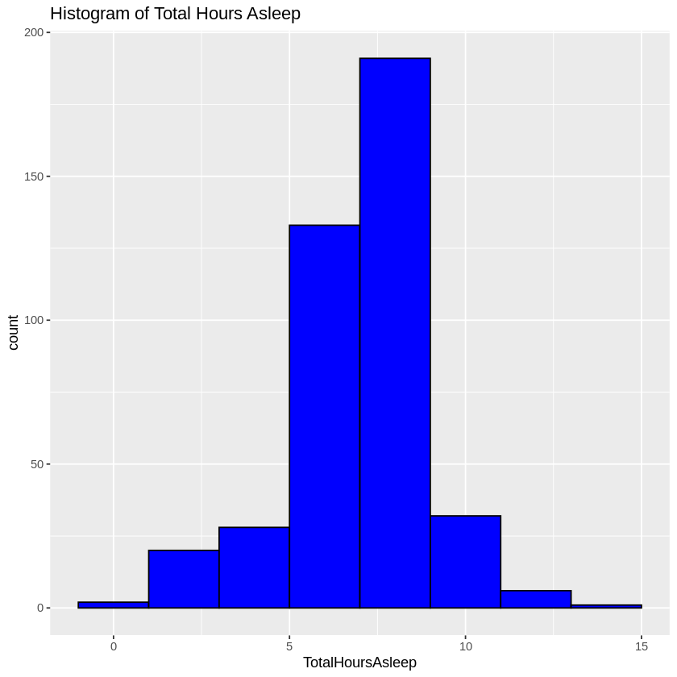

```r
library(ggplot2)

ggplot(subset_FitBit_data_df, aes(x = TotalHoursAsleep)) +
  geom_histogram(binwidth = 2, fill = "blue", color = "black") +
  ggtitle("Histogram of Total Hours Asleep")
```

#### **Scatter Plot:**

#### Below we plotted different calculated activity metrics against hours of sleep. We can visually start to see that there isn't a strong correlations between higher levels of activity and hours slept.

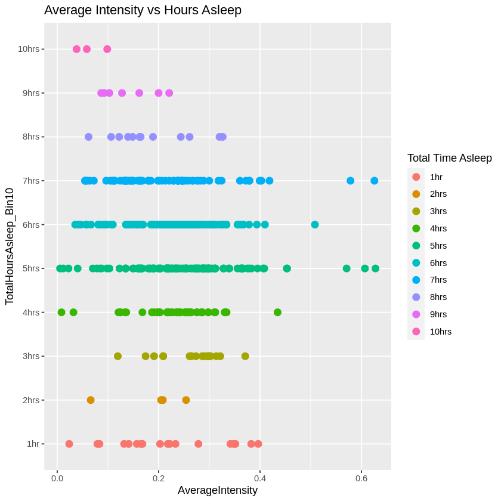

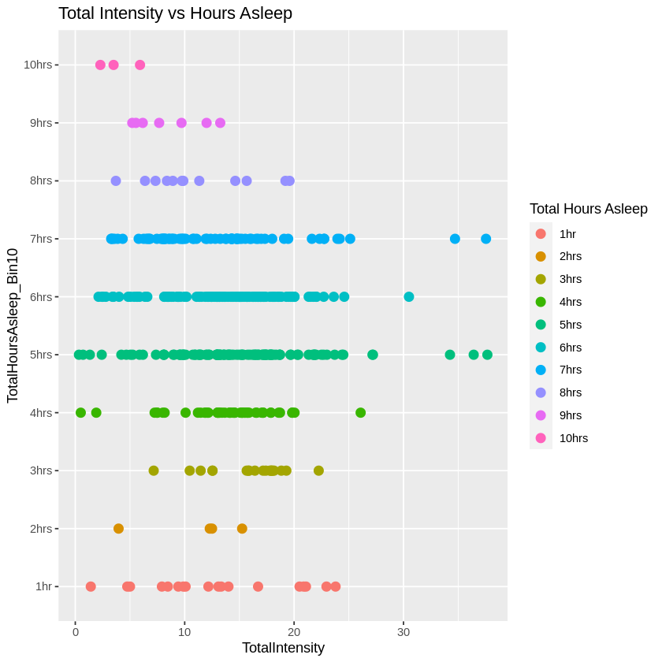

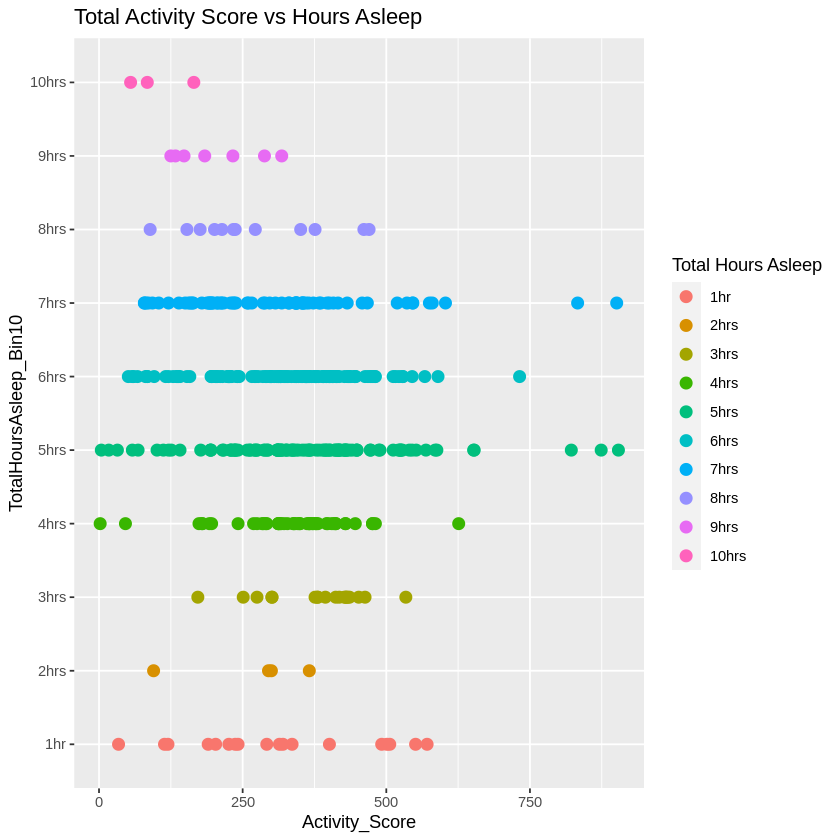

```r
ggplot(subset_FitBit_data_df, aes(x = AverageIntensity, y = TotalHoursAsleep_Bin10)) +
  geom_point(aes(color = TotalHoursAsleep_Bin10), size = 3) +
  ggtitle("Average Intensity vs Hours Asleep") +
  labs(color = "Total Time Asleep")

  ggplot(subset_FitBit_data_df, aes(x = TotalIntensity, y = TotalHoursAsleep_Bin10)) +
  geom_point(aes(color = TotalHoursAsleep_Bin10), size = 3) +
  ggtitle("Total Intensity vs Hours Asleep") +
  labs(color = "Total Hours Asleep")

  ggplot(subset_FitBit_data_df, aes(x = Activity_Score, y = TotalHoursAsleep_Bin10)) +
  geom_point(aes(color = TotalHoursAsleep_Bin10), size = 3) +
  ggtitle("Total Activity Score vs Hours Asleep") +
  labs(color = "Total Hours Asleep")
```

#### **Box Plot:**

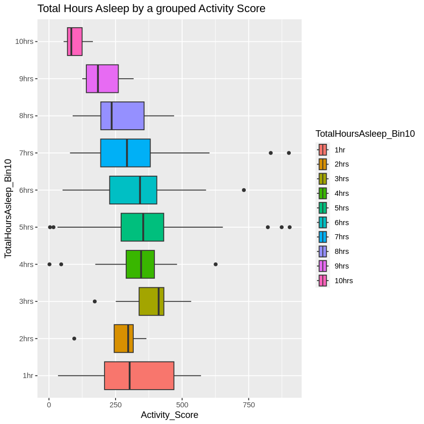

```r
library(dplyr)
ggplot(subset_FitBit_data_df, aes(x = Activity_Score , y = TotalHoursAsleep_Bin10)) +
geom_boxplot(aes(fill = TotalHoursAsleep_Bin10)) +
ggtitle("Total Hours Asleep by a grouped Activity Score")
```

#### **Bar Chart:**

Below we created a bar chart to visualize the number of individuals in each activity score group. We can again see that the majority of individuals do moderate activity or less.

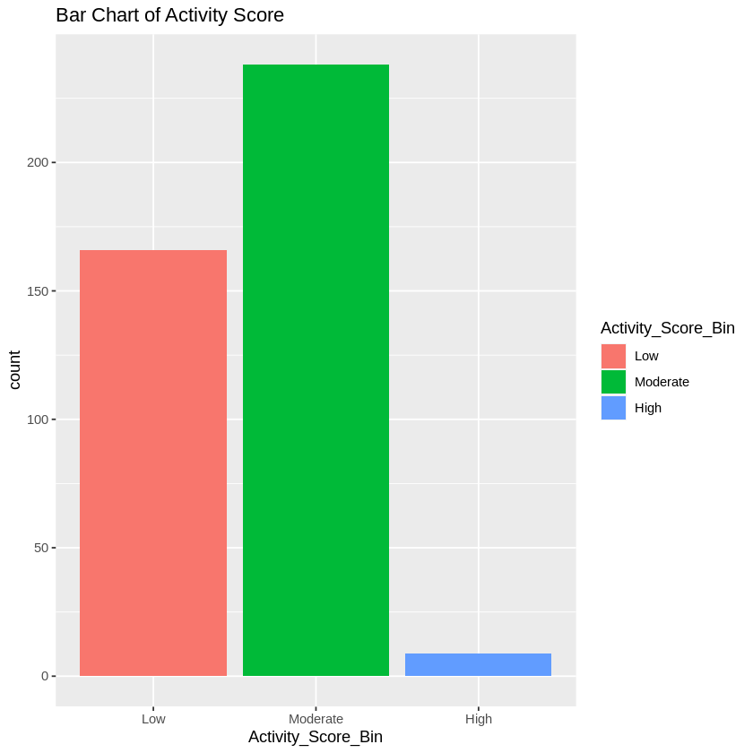

```r
ggplot(subset_FitBit_data_df, aes(x = Activity_Score_Bin)) +
  geom_bar(aes(fill = Activity_Score_Bin)) +
  ggtitle("Bar Chart of Activity Score")
```

## **6) Response Variable:**

#### The response variable "Total hours of sleep" refers to the main area of interest our analysis. It represents the number of hours a person sleeps during a day. Researchers and analysts often study "Total hours of sleep" to understand how various factors, such as physical activity, lifestyle choices, and health conditions may influence a person's sleep patterns. By examining this response variable, we aim to uncover insights into sleep behavior, identify trends or correlations, and make predictions about sleep duration. Hopefully this analysis will help to improve our understanding of sleep-related factors that affect overall health. Our goal is to analyze whether there is a positive impact on sleep as a result of workouts or physical activity.

## **7) Explore Correlations:**

#### Below we want to build better correlations between activity and hours slept. The finding are quite interesting, because we can see that anything above a "low" level activity actually has a negative impact on the hours slept.

```
                  Id           TotalSteps        TotalDistance
          0.08011700          -0.18686650          -0.17214272
   VeryActiveMinutes  FairlyActiveMinutes LightlyActiveMinutes
         -0.09043628          -0.24453463           0.03291407
    SedentaryMinutes             Calories    TotalSleepRecords
         -0.59939401          -0.02852571           0.16591191
  TotalMinutesAsleep       TotalTimeInBed       TotalIntensity
          1.00000000           0.93045745          -0.12356234
    AverageIntensity    Percentage_Asleep       Activity_Score
         -0.12356233           0.26502780          -0.12534221
    TotalHoursAsleep
          1.00000000
```

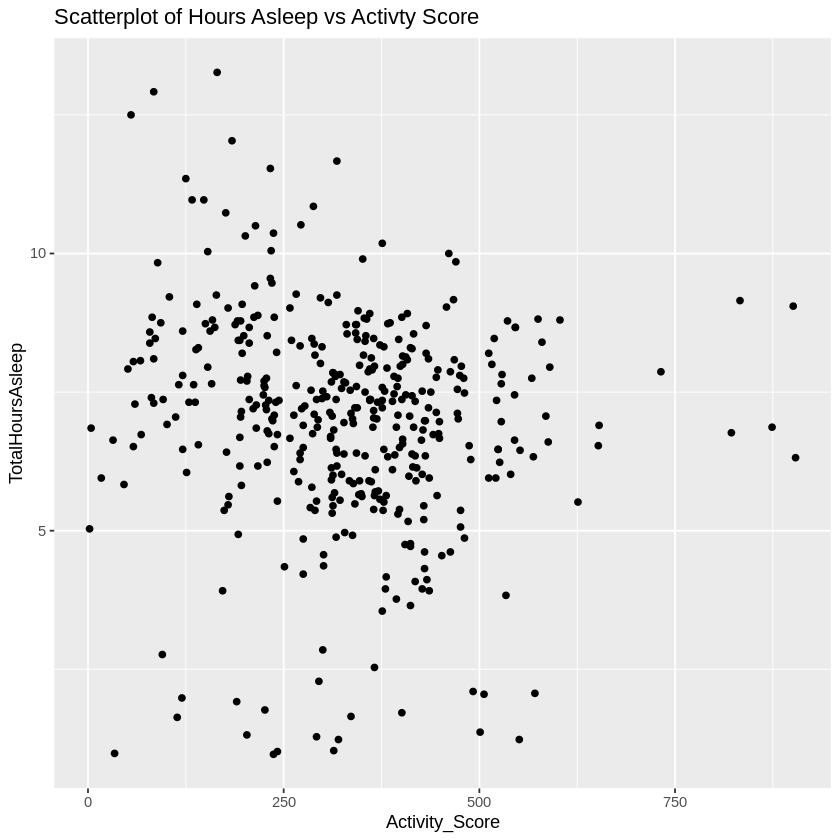

```r
library(ggplot2)

ggplot(subset_FitBit_data_df, aes(x=Activity_Score, y=TotalHoursAsleep)) + geom_point() +
  ggtitle("Scatterplot of Hours Asleep vs Activty Score")

numeric_FitBit_df <- subset_FitBit_data_df[sapply(subset_FitBit_data_df, is.numeric)]


correlations <- cor(numeric_FitBit_df, use="complete.obs")
print(correlations['TotalHoursAsleep',])
```

## **8) Simple Linear Regression:**

1. Activity_Score
2. TotalSteps
3. Total Intensity
4. Very Active Minutes
5. Fairly Active Minutes
6. Lightly Active Minutes

#### 1) Total Hours Asleep vs Activity Score

- The summary of activityModel and graph below shows a negative relationship between Total Hours Asleep and Activity Score. It can be seen that the more active a person is, the less sleep they may actually have compared to a less active person. R-squared value of 0.01571 (or 1.571%) suggests that activity is not a strong predictor of the number of hours of sleep.

```
Call:
lm(formula = TotalHoursAsleep ~ Activity_Score, data = subset_FitBit_data_df)

Residuals:
    Min      1Q  Median      3Q     Max
-6.5159 -0.9295  0.2087  1.2102  5.9935

Coefficients:
                 Estimate Std. Error t value Pr(>|t|)
(Intercept)     7.5578959  0.2413747  31.312   <2e-16 ***
Activity_Score -0.0017253  0.0006736  -2.561   0.0108 *
---
Signif. codes:  0 ‘***’ 0.001 ‘**’ 0.01 ‘*’ 0.05 ‘.’ 0.1 ‘ ’ 1

Residual standard error: 1.959 on 411 degrees of freedom
Multiple R-squared:  0.01571,	Adjusted R-squared:  0.01332
F-statistic:  6.56 on 1 and 411 DF,  p-value: 0.01078
```

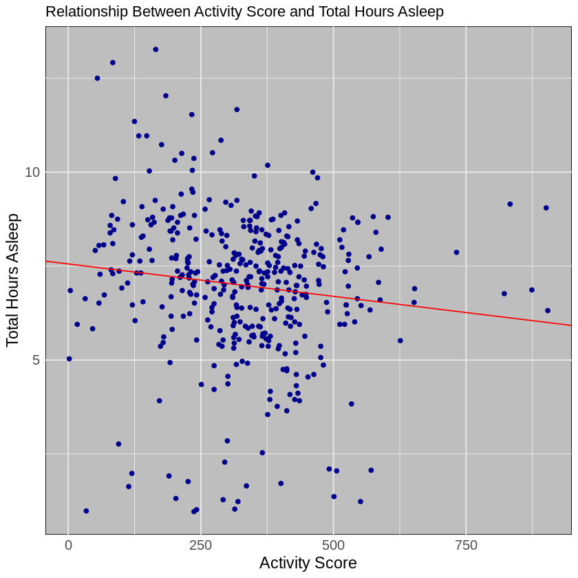

```r
activityModel <- lm(TotalHoursAsleep ~ Activity_Score, subset_FitBit_data_df)
summary(activityModel)

library(ggplot2)

plot <- ggplot(data = subset_FitBit_data_df, aes(x = Activity_Score , y = TotalHoursAsleep)) +
  geom_point(color = "darkblue", shape = 19) +
  geom_abline(intercept = activityModel$coefficients[1], slope = activityModel$coefficients[2], color = "red", linetype = "solid") +
  labs(x = "Activity Score", y = "Total Hours Asleep") +
  ggtitle("Relationship Between Activity Score and Total Hours Asleep") +
  theme_minimal() +
  theme(axis.text = element_text(size = 12), axis.title = element_text(size = 14),
        panel.background = element_rect(fill = "grey"))


print(plot)
```

#### 2) TotalHoursAsleep vs TotalSteps

- The graph below indicates the relationship between Total hours asleep and Total steps. The linear regression model known as stepsModel examines the relationship between total hours of sleep (TotalHoursAsleep) and total number of steps (TotalSteps) which yields a slightly stronger but still modest relationship compared to the previous model. The multiple R-squared value of 0.03492 indicates that approximately 3.492% of the variability in sleep duration can be explained by step counts, which is a slightly higher proportion than in the previous model.The stepsModel focusing on sleep and steps shows a slightly higher explanatory power, though still not substantial. This suggests that the total number of steps taken may have a slightly greater influence on sleep duration compared to the ActivityScore variables.

```
Call:
lm(formula = TotalHoursAsleep ~ TotalSteps, data = subset_FitBit_data_df)

Residuals:
    Min      1Q  Median      3Q     Max
-6.4369 -0.9444  0.2144  1.1696  5.8514

Coefficients:
              Estimate Std. Error t value Pr(>|t|)
(Intercept)  7.748e+00  2.184e-01  35.485  < 2e-16 ***
TotalSteps  -8.867e-05  2.299e-05  -3.856 0.000134 ***
---
Signif. codes:  0 ‘***’ 0.001 ‘**’ 0.01 ‘*’ 0.05 ‘.’ 0.1 ‘ ’ 1

Residual standard error: 1.94 on 411 degrees of freedom
Multiple R-squared:  0.03492,	Adjusted R-squared:  0.03257
F-statistic: 14.87 on 1 and 411 DF,  p-value: 0.0001336
```

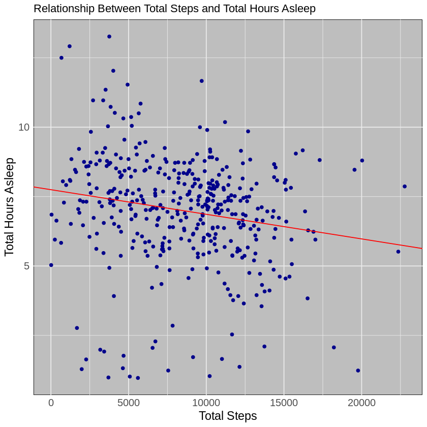

```r
stepsModel <- lm(TotalHoursAsleep ~ TotalSteps, subset_FitBit_data_df)
summary(stepsModel)

library(ggplot2)

plot <- ggplot(data = subset_FitBit_data_df, aes(x = TotalSteps, y = TotalHoursAsleep)) +
  geom_point(color = "darkblue", shape = 19) +
  geom_abline(intercept = stepsModel$coefficients[1], slope = stepsModel$coefficients[2], color = "red", linetype = "solid") +
  labs(x = "Total Steps", y = "Total Hours Asleep") +
  ggtitle("Relationship Between Total Steps and Total Hours Asleep") +
  theme_minimal() +
  theme(axis.text = element_text(size = 12), axis.title = element_text(size = 14),
        panel.background = element_rect(fill = "grey"))


print(plot)
```

#### 3) TotalHoursAsleep vs Intensity

- The graph below indicates the relationship between Total Hours Asleep and Total Intensity. Total Intensity can be categorised as the average intensity between highly active and sedentary. The multiple R-squared value of 0.01527 suggests that approximately 1.527% of the variability in total hours of sleep which is similar to activityModel. The coefficient for the TotalIntensity variable (TotalIntensity) is estimated to be -2.4667. This means that for each unit increase in TotalIntensity, the model predicts a decrease of approximately 2.47 minutes in TotalMinutesAsleep. In other words, total intensity has an effect on total hours of sleep but the relationship is statistically weak and there are other factors which might affect the sleep.

```
Call:
lm(formula = TotalHoursAsleep ~ TotalIntensity, data = subset_FitBit_data_df)

Residuals:
    Min      1Q  Median      3Q     Max
-6.5160 -0.9319  0.2104  1.2081  5.9524

Coefficients:
               Estimate Std. Error t value Pr(>|t|)
(Intercept)     7.55754    0.24423  30.945   <2e-16 ***
TotalIntensity -0.04111    0.01629  -2.524    0.012 *
---
Signif. codes:  0 ‘***’ 0.001 ‘**’ 0.01 ‘*’ 0.05 ‘.’ 0.1 ‘ ’ 1

Residual standard error: 1.96 on 411 degrees of freedom
Multiple R-squared:  0.01527,	Adjusted R-squared:  0.01287
F-statistic: 6.372 on 1 and 411 DF,  p-value: 0.01197
```

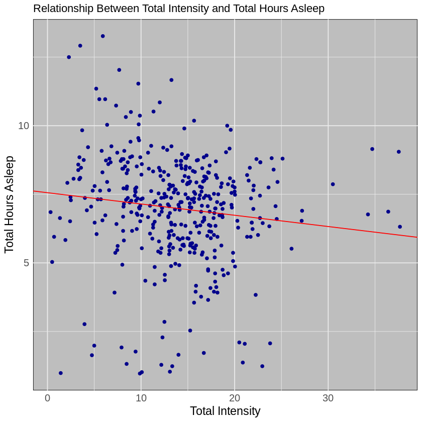

```r
intensityModel<- lm(TotalHoursAsleep ~ TotalIntensity, subset_FitBit_data_df)
summary(intensityModel)

library(ggplot2)

plot <- ggplot(data = subset_FitBit_data_df, aes(x = TotalIntensity, y = TotalHoursAsleep)) +
  geom_point(color = "darkblue", shape = 19) +
  geom_abline(intercept = intensityModel$coefficients[1], slope = intensityModel$coefficients[2], color = "red", linetype = "solid") +
  labs(x = "Total Intensity", y = "Total Hours Asleep") +
  ggtitle("Relationship Between Total Intensity and Total Hours Asleep") +
  theme_minimal() +
  theme(axis.text = element_text(size = 12), axis.title = element_text(size = 14),
        panel.background = element_rect(fill = "grey"))


print(plot)
```

#### 4) VeryActiveMinutes vs TotalHoursAsleep

- The graph below indicates the relationship between Total Hours Asleep vs Very active Minutes. Very Active minutes can be categorised as the duration of minutes when a person is doing a highly active or strenous tasks such as lifting heavy weights, sprinting, etc. The coefficient for the VeryActiveMinutes variable is estimated to be -0.004902. This means that for each additional minute of very active activity, the model predicts a decrease of approximately 0.0049 hours (or about 17.64 seconds) in TotalHoursAsleep. The linear regression model suggests a very weak relationship with Total hours of Sleep.

```
Call:
lm(formula = TotalHoursAsleep ~ VeryActiveMinutes, data = subset_FitBit_data_df)

Residuals:
    Min      1Q  Median      3Q     Max
-6.1479 -0.9185  0.2246  1.1854  6.1570

Coefficients:
                   Estimate Std. Error t value Pr(>|t|)
(Intercept)        7.114600   0.117746  60.423   <2e-16 ***
VeryActiveMinutes -0.004902   0.002663  -1.841   0.0663 .
---
Signif. codes:  0 ‘***’ 0.001 ‘**’ 0.01 ‘*’ 0.05 ‘.’ 0.1 ‘ ’ 1

Residual standard error: 1.967 on 411 degrees of freedom
Multiple R-squared:  0.008179,	Adjusted R-squared:  0.005766
F-statistic: 3.389 on 1 and 411 DF,  p-value: 0.06635
```

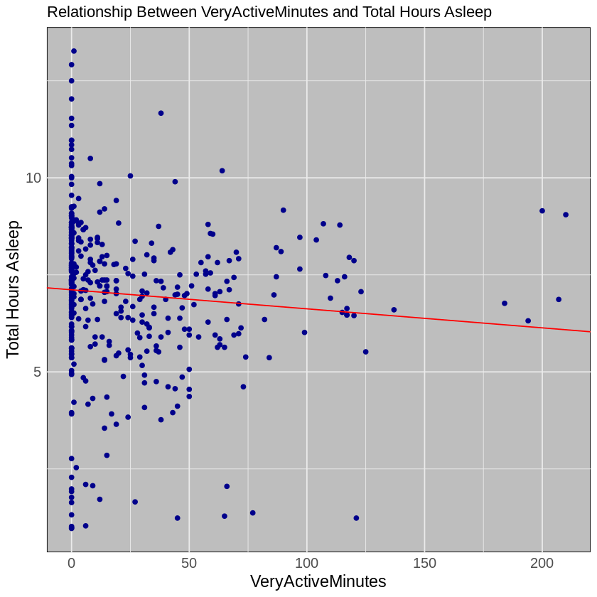

```r
VeryActiveMinutesModel <- lm(TotalHoursAsleep ~ VeryActiveMinutes, subset_FitBit_data_df)
summary(VeryActiveMinutesModel)

library(ggplot2)

plot <- ggplot(data = subset_FitBit_data_df, aes(x = VeryActiveMinutes, y = TotalHoursAsleep)) +
  geom_point(color = "darkblue", shape = 19) +
  geom_abline(intercept = VeryActiveMinutesModel$coefficients[1], slope = VeryActiveMinutesModel$coefficients[2], color = "red", linetype = "solid") +
  labs(x = "VeryActiveMinutes", y = "Total Hours Asleep") +
  ggtitle("Relationship Between VeryActiveMinutes and Total Hours Asleep") +
  theme_minimal() +
  theme(axis.text = element_text(size = 12), axis.title = element_text(size = 14),

        panel.background = element_rect(fill = "grey"))


print(plot)
```

#### 5) FairlyActiveMinutes vs TotalHoursAsleep

- The graph below indicates relationship between Total Hours Asleep vs FairlyActiveMinutes. Fairly Active minutes are the duration in minutes when a person does moderate intensity tasks such as lifting light weights which are not as rigorous as Very Active minutes. FairlyActiveMinutesModel shows a stronger relationship with TotalHoursAsleep, as evident by the higher R-squared values 0.0598. The coefficient for FairlyActiveMinutes (-0.021529) implies a larger effect size which is a decrease of approximately 0.0215 hours, or about 77.4 seconds, in TotalHoursAsleep for each additional minute of fairly active activity. The inclusion of FairlyActiveMinutes as a predictor explains a higher proportion of the variability in sleep duration, and the effect size is larger, suggesting that fairly active minutes may have a more significant impact on sleep patterns than very active minutes.

```
Call:
lm(formula = TotalHoursAsleep ~ FairlyActiveMinutes, data = subset_FitBit_data_df)

Residuals:
    Min      1Q  Median      3Q     Max
-6.4128 -0.8759  0.1858  1.1372  6.0379

Coefficients:
                     Estimate Std. Error t value Pr(>|t|)
(Intercept)          7.379475   0.121028  60.973  < 2e-16 ***
FairlyActiveMinutes -0.021529   0.004211  -5.113 4.88e-07 ***
---
Signif. codes:  0 ‘***’ 0.001 ‘**’ 0.01 ‘*’ 0.05 ‘.’ 0.1 ‘ ’ 1

Residual standard error: 1.915 on 411 degrees of freedom
Multiple R-squared:  0.0598,	Adjusted R-squared:  0.05751
F-statistic: 26.14 on 1 and 411 DF,  p-value: 4.878e-07
```

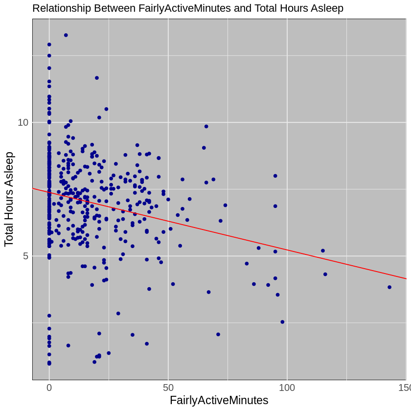

```r
FairlyActiveMinutesModel <- lm(TotalHoursAsleep ~ FairlyActiveMinutes, subset_FitBit_data_df)
summary(FairlyActiveMinutesModel)

library(ggplot2)

plot <- ggplot(data = subset_FitBit_data_df, aes(x = FairlyActiveMinutes, y = TotalHoursAsleep)) +
  geom_point(color = "darkblue", shape = 19) +
  geom_abline(intercept = FairlyActiveMinutesModel$coefficients[1], slope = FairlyActiveMinutesModel$coefficients[2], color = "red", linetype = "solid") +
  labs(x = "FairlyActiveMinutes", y = "Total Hours Asleep") +
  ggtitle("Relationship Between FairlyActiveMinutes and Total Hours Asleep") +
  theme_minimal() +
  theme(axis.text = element_text(size = 12), axis.title = element_text(size = 14),
        panel.background = element_rect(fill = "grey"))


print(plot)
```

#### 6) LightlyActiveMinutes vs TotalHoursAsleep

```
Call:
lm(formula = TotalHoursAsleep ~ LightlyActiveMinutes, data = subset_FitBit_data_df)

Residuals:
    Min      1Q  Median      3Q     Max
-6.0395 -0.9180  0.1931  1.1863  6.3268

Coefficients:
                      Estimate Std. Error t value Pr(>|t|)
(Intercept)          6.8296089  0.2606861  26.199   <2e-16 ***
LightlyActiveMinutes 0.0007448  0.0011156   0.668    0.505
---
Signif. codes:  0 ‘***’ 0.001 ‘**’ 0.01 ‘*’ 0.05 ‘.’ 0.1 ‘ ’ 1

Residual standard error: 1.974 on 411 degrees of freedom
Multiple R-squared:  0.001083,	Adjusted R-squared:  -0.001347
F-statistic: 0.4457 on 1 and 411 DF,  p-value: 0.5047
```

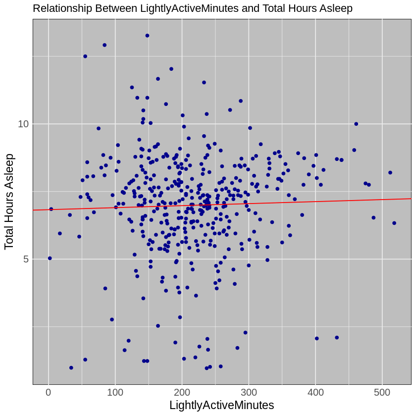

```r
LightlyActiveMinutesModelHours <- lm(TotalHoursAsleep ~ LightlyActiveMinutes, subset_FitBit_data_df)
summary(LightlyActiveMinutesModelHours)

library(ggplot2)

plot <- ggplot(data = subset_FitBit_data_df, aes(x = LightlyActiveMinutes, y = TotalHoursAsleep)) +
  geom_point(color = "darkblue", shape = 19) +
  geom_abline(intercept = LightlyActiveMinutesModelHours$coefficients[1], slope = LightlyActiveMinutesModelHours$coefficients[2], color = "red", linetype = "solid") +
  labs(x = "LightlyActiveMinutes", y = "Total Hours Asleep") +
  ggtitle("Relationship Between LightlyActiveMinutes and Total Hours Asleep") +
  theme_minimal() +
  theme(axis.text = element_text(size = 12), axis.title = element_text(size = 14),
        panel.background = element_rect(fill = "grey"))


print(plot)
```

## **9) Multiple Linear Regression:**

#### Based on the results obtained from all the simple linear regression models, we proceeded with designing multiple linear regression models using combinations of variables used in the simple linear models.

#### 1) The first multiple linear regression model we created contains the three different categories of active minutes: LightlyActiveMinutes, FairlyActiveMinutes and VeryActiveMinutes. Summary of this model shows that the coefficient for only FairlyActiveMinutes is statistically significant, so we can proceed building more multiple linear regression models using that variable.

```r
multipleMinutesModel <- lm(TotalHoursAsleep ~ LightlyActiveMinutes + FairlyActiveMinutes + VeryActiveMinutes, subset_FitBit_data_df)
summary(multipleMinutesModel)
```

```
Call:
lm(formula = TotalHoursAsleep ~ LightlyActiveMinutes + FairlyActiveMinutes +
    VeryActiveMinutes, data = subset_FitBit_data_df)

Residuals:
    Min      1Q  Median      3Q     Max
-6.4322 -0.9245  0.2036  1.1437  6.0745

Coefficients:
                       Estimate Std. Error t value Pr(>|t|)
(Intercept)           7.2460680  0.2826244  25.639  < 2e-16 ***
LightlyActiveMinutes  0.0006448  0.0011111   0.580    0.562
FairlyActiveMinutes  -0.0212768  0.0044550  -4.776  2.5e-06 ***
VeryActiveMinutes    -0.0004354  0.0028052  -0.155    0.877
---
Signif. codes:  0 ‘***’ 0.001 ‘**’ 0.01 ‘*’ 0.05 ‘.’ 0.1 ‘ ’ 1

Residual standard error: 1.919 on 409 degrees of freedom
Multiple R-squared:  0.06076,	Adjusted R-squared:  0.05387
F-statistic:  8.82 on 3 and 409 DF,  p-value: 1.118e-05
```

#### 2) The model below combines all the other variables we used in the simple linear regressions with FairlyActiveMinutes. We can observe an improvement in the r-squared and adjusted r-squared values.This also shows that TotalSteps has a statistically significant coefficient for predicting TotalHoursAsleep but it's not as significant as the coefficient of FairlyActiveMinutes.

#### Model equation:

#### TotalHoursAsleep = 7.41 - 0.0000949(TotalSteps) + 0.0155(TotalIntensity) + 0.00162(Activity_Score) - 0.0194(FairlyActiveMinutes)

```r
multipleAllModel <- lm(TotalHoursAsleep ~ TotalSteps + TotalIntensity + Activity_Score + FairlyActiveMinutes, subset_FitBit_data_df)
summary(multipleAllModel)
```

```
Call:
lm(formula = TotalHoursAsleep ~ TotalSteps + TotalIntensity +
    Activity_Score + FairlyActiveMinutes, data = subset_FitBit_data_df)

Residuals:
    Min      1Q  Median      3Q     Max
-6.4553 -0.8981  0.1724  1.1208  5.9946

Coefficients:
                      Estimate Std. Error t value Pr(>|t|)
(Intercept)          7.405e+00  2.461e-01  30.085   <2e-16 ***
TotalSteps          -9.485e-05  4.364e-05  -2.174   0.0303 *
TotalIntensity       1.545e-02  1.319e-01   0.117   0.9068
Activity_Score       1.624e-03  5.578e-03   0.291   0.7712
FairlyActiveMinutes -1.940e-02  5.170e-03  -3.753   0.0002 ***
---
Signif. codes:  0 ‘***’ 0.001 ‘**’ 0.01 ‘*’ 0.05 ‘.’ 0.1 ‘ ’ 1

Residual standard error: 1.911 on 408 degrees of freedom
Multiple R-squared:  0.07072,	Adjusted R-squared:  0.06161
F-statistic: 7.762 on 4 and 408 DF,  p-value: 4.9e-06
```

#### 3) Here, we created polynomial regression model using the 2 variables with the best correlations to total hours slept as seen in the previous multiple regression models. The difference between the values for r-squared and adjusted r-squared is small, so we believe that this model does not necessarily make the prediction for TotalHoursAsleep more accurate but rather highlights that FairlyActiveMinutes is the best predictor variable within the dataset for total hours slept.

#### Model equation:

#### TotalHoursAsleep = 7.53 - 0.0418(FairlyActiveMinutes) - 0.000316(FairlyActiveMinutes^2) + 0.0000258(TotalSteps) - 0.00000000721(TotalSteps^2) + 0.00000436(FairlyActiveMinutes*TotalSteps)

```r
polyModel <- lm(TotalHoursAsleep ~ FairlyActiveMinutes + TotalSteps + I(FairlyActiveMinutes^2) + I(TotalSteps^2) + FairlyActiveMinutes:TotalSteps, subset_FitBit_data_df)
summary(polyModel)
```

```
Call:
lm(formula = TotalHoursAsleep ~ FairlyActiveMinutes + TotalSteps +
    I(FairlyActiveMinutes^2) + I(TotalSteps^2) + FairlyActiveMinutes:TotalSteps,
    data = subset_FitBit_data_df)

Residuals:
    Min      1Q  Median      3Q     Max
-6.5474 -0.8915  0.1763  1.1366  5.9309

Coefficients:
                                 Estimate Std. Error t value Pr(>|t|)
(Intercept)                     7.534e+00  3.441e-01  21.896   <2e-16 ***
FairlyActiveMinutes            -4.180e-02  2.121e-02  -1.970   0.0495 *
TotalSteps                      2.580e-05  9.174e-05   0.281   0.7787
I(FairlyActiveMinutes^2)       -3.158e-04  1.593e-04  -1.982   0.0482 *
I(TotalSteps^2)                -7.209e-09  5.803e-09  -1.242   0.2149
FairlyActiveMinutes:TotalSteps  4.356e-06  2.293e-06   1.900   0.0582 .
---
Signif. codes:  0 ‘***’ 0.001 ‘**’ 0.01 ‘*’ 0.05 ‘.’ 0.1 ‘ ’ 1

Residual standard error: 1.91 on 407 degrees of freedom
Multiple R-squared:  0.07335,	Adjusted R-squared:  0.06196
F-statistic: 6.443 on 5 and 407 DF,  p-value: 8.881e-06
```

#### **Summary:**

#### Upon comparing the simple regression results with the multiple regression results, several insights can be taken. In the simple regressions, individual predictors like Activity Score, Total Steps, Total Intensity, Very Active Minutes, Fairly Active Minutes, and Lightly Active Minutes were assessed for their relationship with Total Hours Asleep. Among them, the model involving Fairly Active Minutes had the strongest relationship with Total Hours Asleep, as evidenced by the highest R-squared value of 0.0598. However, when considering the multiple regression models, the predictors were combined in various configurations to examine their joint impact. The R-squared values in these models, ranging from 0.06076 to 0.07335, are generally higher than those in the simple regressions, indicating that combining predictors can better explain the variability in sleep hours. The model incorporating Fairly Active Minutes, Total Steps, their squared terms, and interaction term had the highest R-squared value among multiple regressions, suggesting it explains the most variance in Total Hours Asleep.

## **Project Report**

#### **Introduction:** After looking into the data collected by Fitbit. We have found a better look at what aspects of daily activity have on the amount of sleep a person gets.

#### **Simple Regression Analysis:** Initially, we analyzed each activity separately. This means we looked at factors like total steps, exercise intensity, and the various minutes of activity throughout the day. We wanted to see which single factor might be the biggest influencer on sleep duration. See plot below for R-squared values of each of our regression models.

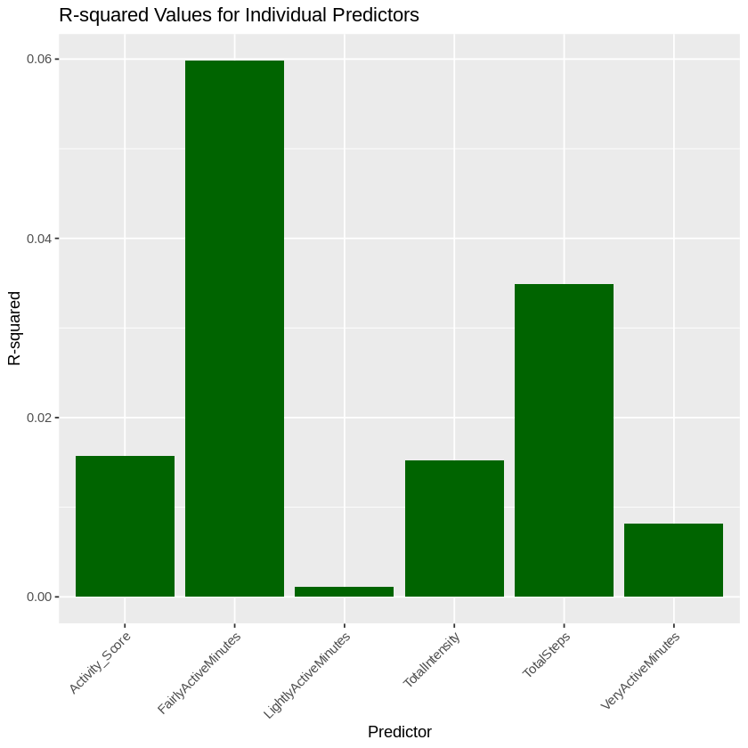

```r
predictor_data <- data.frame(
Predictor = c("Activity_Score", "TotalSteps", "TotalIntensity", "VeryActiveMinutes", "FairlyActiveMinutes", "LightlyActiveMinutes"),
R_squared = c(0.01571, 0.03492, 0.01527, 0.008179, 0.0598, 0.001083)
)


library(ggplot2)

ggplot(predictor_data, aes(x = Predictor, y = R_squared)) +
geom_bar(stat = "identity", fill = "darkgreen") +
labs(title = "R-squared Values for Individual Predictors",
x = "Predictor",
y = "R-squared") +
theme(axis.text.x = element_text(angle = 45, hjust = 1))
```

#### **Major Finding:** Among these single factors, the time you're "fairly active" stood out. It seemed to have the most correlation with your sleep duration. To be more precise, its connection strength (or R-squared value) was 0.0598.

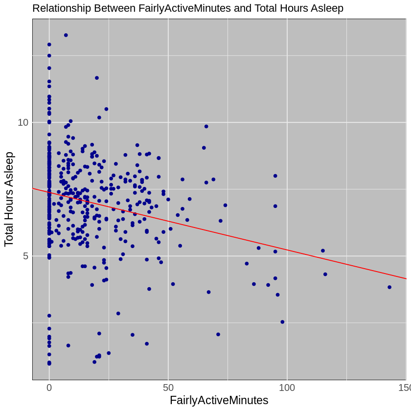

```r
FairlyActiveMinutesModel <- lm(TotalHoursAsleep ~ FairlyActiveMinutes, subset_FitBit_data_df)


library(ggplot2)

plot <- ggplot(data = subset_FitBit_data_df, aes(x = FairlyActiveMinutes, y = TotalHoursAsleep)) +
geom_point(color = "darkblue", shape = 19) +
geom_abline(intercept = FairlyActiveMinutesModel$coefficients[1], slope = FairlyActiveMinutesModel$coefficients[2], color = "red", linetype = "solid") +
labs(x = "FairlyActiveMinutes", y = "Total Hours Asleep") +
ggtitle("Relationship Between FairlyActiveMinutes and Total Hours Asleep") +
theme_minimal() +
theme(axis.text = element_text(size = 12), axis.title = element_text(size = 14),
panel.background = element_rect(fill = "grey"))


print(plot)
```

#### **Future Study Recommendation** In the future, to build a more comprehensive analysis and derive implications between sleep and physical activity, a larger dataset will a more even spread of data and values would be needed. Having said that, it would be extremely difficult to cherry pick a range of different individuals with a varying levels of physical activity and sleep patterns.

## **Statement of Originality**

#### "No other similar published works for linear regression found with same dataset" specified